# DATA621_HW1_team

Matthew Baker, Misha Kollontai, Erinda Budo, Don Padmaperuma, Subhalaxmi Rout

9/20/2020

## Overview

In this homework assignment, we will explore, analyze and model a data set containing approximately 2200 records. Each record represents a professional baseball team from the years 1871 to 2006 inclusive. Each record has the performance of the team for the given year, with all of the statistics adjusted to match the performance of a 162 game season. Our objective is to build a multiple linear regression model on the training data to predict the number of wins for the team.

## Libraries

```r
library(tidyverse)
library(ggcorrplot)
library(pastecs)
library(reshape)
library(ggplot2)
library(mice)
library(VIM)
library(corrplot)
library(car)
library(jtools)
```

## Data Import and Prep

The original data was loaded containing 2276 rows and 16 columns related to batting, base run, pitching, and fielding. A summary and boxplots of all variables suggest some columns have missing data, and some may contain outliers.

```r
#Read the training and test data
MB_train <- read.csv("https://raw.githubusercontent.com/mkollontai/DATA621_GroupWork/master/HW1/moneyball-training-data.csv")
MB_test <- read.csv("https://raw.githubusercontent.com/mkollontai/DATA621_GroupWork/master/HW1/moneyball-evaluation-data.csv")
```

```r
dim(MB_train)
```

```
## [1] 2276   17
```

```r
head(MB_train)
```

```
##   INDEX TARGET_WINS TEAM_BATTING_H TEAM_BATTING_2B TEAM_BATTING_3B
## 1     1          39           1445             194              39
## 2     2          70           1339             219              22
## 3     3          86           1377             232              35
## 4     4          70           1387             209              38
## 5     5          82           1297             186              27
## 6     6          75           1279             200              36
##   TEAM_BATTING_HR TEAM_BATTING_BB TEAM_BATTING_SO TEAM_BASERUN_SB
## 1              13             143             842              NA
## 2             190             685            1075              37
## 3             137             602             917              46
## 4              96             451             922              43
## 5             102             472             920              49
## 6              92             443             973             107
##   TEAM_BASERUN_CS TEAM_BATTING_HBP TEAM_PITCHING_H TEAM_PITCHING_HR
## 1              NA               NA            9364               84
## 2              28               NA            1347              191
## 3              27               NA            1377              137
## 4              30               NA            1396               97
## 5              39               NA            1297              102
## 6              59               NA            1279               92
##   TEAM_PITCHING_BB TEAM_PITCHING_SO TEAM_FIELDING_E TEAM_FIELDING_DP
## 1              927             5456            1011               NA
## 2              689             1082             193              155
## 3              602              917             175              153
## 4              454              928             164              156
## 5              472              920             138              168
## 6              443              973             123              149
```

```r
#elimination index column in both data files
MB_train <- MB_train[-1]
MB_test <- MB_train[-1]
```

```r
#subset the batting  stats
 MB_train_bat<-MB_train[c("TEAM_BATTING_H"  , "TEAM_BATTING_2B" , "TEAM_BATTING_3B" , "TEAM_BATTING_HR", "TEAM_BATTING_BB" , "TEAM_BATTING_SO")]

#subset the baserunning  stats
 MB_train_base<-MB_train[c("TEAM_BASERUN_SB" , "TEAM_BASERUN_CS")]

#subset the fielding  stats
 MB_train_field<-MB_train[c("TEAM_FIELDING_E",  "TEAM_FIELDING_DP")]

#subset the pitching  stats
 MB_train_pitch<-MB_train[c("TEAM_PITCHING_H" ,"TEAM_PITCHING_HR" ,"TEAM_PITCHING_BB" ,"TEAM_PITCHING_SO")]
```

## Data Summaries

We can only use the variables given to us (or variables that we derive from the variables provided). Below codes shows the variables of interest in the data set:

```r
summary(MB_train)
```

```
##   TARGET_WINS     TEAM_BATTING_H TEAM_BATTING_2B TEAM_BATTING_3B
##  Min.   :  0.00   Min.   : 891   Min.   : 69.0   Min.   :  0.00
##  1st Qu.: 71.00   1st Qu.:1383   1st Qu.:208.0   1st Qu.: 34.00
##  Median : 82.00   Median :1454   Median :238.0   Median : 47.00
##  Mean   : 80.79   Mean   :1469   Mean   :241.2   Mean   : 55.25
##  3rd Qu.: 92.00   3rd Qu.:1537   3rd Qu.:273.0   3rd Qu.: 72.00
##  Max.   :146.00   Max.   :2554   Max.   :458.0   Max.   :223.00
##
##  TEAM_BATTING_HR  TEAM_BATTING_BB TEAM_BATTING_SO  TEAM_BASERUN_SB
##  Min.   :  0.00   Min.   :  0.0   Min.   :   0.0   Min.   :  0.0
##  1st Qu.: 42.00   1st Qu.:451.0   1st Qu.: 548.0   1st Qu.: 66.0
##  Median :102.00   Median :512.0   Median : 750.0   Median :101.0
##  Mean   : 99.61   Mean   :501.6   Mean   : 735.6   Mean   :124.8
##  3rd Qu.:147.00   3rd Qu.:580.0   3rd Qu.: 930.0   3rd Qu.:156.0
##  Max.   :264.00   Max.   :878.0   Max.   :1399.0   Max.   :697.0
##                                   NA's   :102      NA's   :131
##  TEAM_BASERUN_CS TEAM_BATTING_HBP TEAM_PITCHING_H TEAM_PITCHING_HR
##  Min.   :  0.0   Min.   :29.00    Min.   : 1137   Min.   :  0.0
##  1st Qu.: 38.0   1st Qu.:50.50    1st Qu.: 1419   1st Qu.: 50.0
##  Median : 49.0   Median :58.00    Median : 1518   Median :107.0
##  Mean   : 52.8   Mean   :59.36    Mean   : 1779   Mean   :105.7
##  3rd Qu.: 62.0   3rd Qu.:67.00    3rd Qu.: 1682   3rd Qu.:150.0
##  Max.   :201.0   Max.   :95.00    Max.   :30132   Max.   :343.0
##  NA's   :772     NA's   :2085
##  TEAM_PITCHING_BB TEAM_PITCHING_SO  TEAM_FIELDING_E  TEAM_FIELDING_DP
##  Min.   :   0.0   Min.   :    0.0   Min.   :  65.0   Min.   : 52.0
##  1st Qu.: 476.0   1st Qu.:  615.0   1st Qu.: 127.0   1st Qu.:131.0
##  Median : 536.5   Median :  813.5   Median : 159.0   Median :149.0
##  Mean   : 553.0   Mean   :  817.7   Mean   : 246.5   Mean   :146.4
##  3rd Qu.: 611.0   3rd Qu.:  968.0   3rd Qu.: 249.2   3rd Qu.:164.0
##  Max.   :3645.0   Max.   :19278.0   Max.   :1898.0   Max.   :228.0
##                   NA's   :102                        NA's   :286
```

```r
stat.desc(MB_train, basic = F)
```

```
##              TARGET_WINS TEAM_BATTING_H TEAM_BATTING_2B TEAM_BATTING_3B
## median        82.0000000   1.454000e+03     238.0000000      47.0000000
## mean          80.7908612   1.469270e+03     241.2469244      55.2500000
## SE.mean        0.3301823   3.030789e+00       0.9810087       0.5856226
## CI.mean.0.95   0.6474899   5.943400e+00       1.9237652       1.1484102
## var          248.1303077   2.090661e+04    2190.3724081     780.5629670
## std.dev       15.7521525   1.445912e+02      46.8014146      27.9385570
## coef.var       0.1949744   9.841024e-02       0.1939980       0.5056752
##              TEAM_BATTING_HR TEAM_BATTING_BB TEAM_BATTING_SO
## median           102.0000000    5.120000e+02    7.500000e+02
## mean              99.6120387    5.015589e+02    7.356053e+02
## SE.mean            1.2691285    2.571315e+00    5.330191e+00
## CI.mean.0.95       2.4887702    5.042367e+00    1.045281e+01
## var             3665.9237056    1.504814e+04    6.176538e+04
## std.dev           60.5468720    1.226709e+02    2.485264e+02
## coef.var           0.6078269    2.445792e-01    3.378529e-01
##              TEAM_BASERUN_SB TEAM_BASERUN_CS TEAM_BATTING_HBP
## median           101.0000000      49.0000000       58.0000000
## mean             124.7617716      52.8038564       59.3560209
## SE.mean            1.8955584       0.5919414        0.9382681
## CI.mean.0.95       3.7173247       1.1611188        1.8507602
## var             7707.2888364     526.9934382      168.1462662
## std.dev           87.7911660      22.9563376       12.9671225
## coef.var           0.7036704       0.4347474        0.2184635
##              TEAM_PITCHING_H TEAM_PITCHING_HR TEAM_PITCHING_BB
## median          1.518000e+03      107.0000000     5.365000e+02
## mean            1.779210e+03      105.6985940     5.530079e+02
## SE.mean         2.948896e+01        1.2848886     3.487032e+00
## CI.mean.0.95    5.782807e+01        2.5196759     6.838095e+00
## var             1.979207e+06     3757.5363673     2.767477e+04
## std.dev         1.406843e+03       61.2987469     1.663574e+02
## coef.var        7.907119e-01        0.5799391     3.008228e-01
##              TEAM_PITCHING_SO TEAM_FIELDING_E TEAM_FIELDING_DP
## median           8.135000e+02    1.590000e+02      149.0000000
## mean             8.177305e+02    2.464807e+02      146.3879397
## SE.mean          1.186212e+01    4.774328e+00        0.5879114
## CI.mean.0.95     2.326228e+01    9.362492e+00        1.1529868
## var              3.059031e+05    5.187962e+04      687.8232833
## std.dev          5.530850e+02    2.277710e+02       26.2263853
## coef.var         6.763659e-01    9.240926e-01        0.1791567
```

## Data Exploration Visualizations

Let’s take a closer look at the number of wins or **TARGET_WINS** variable.

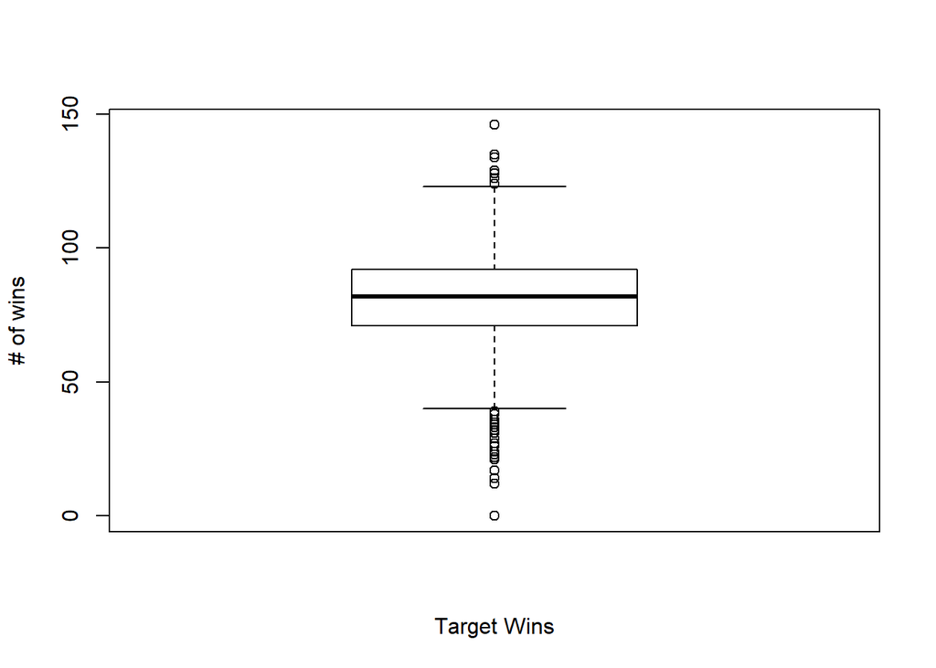

```r
boxplot(MB_train$TARGET_WINS, xlab = "Target Wins", ylab = "# of wins")
```

Let’s look at all of the metrics in order to evaluate the presence of outliers and quality of the data overall.

[figure not shown]

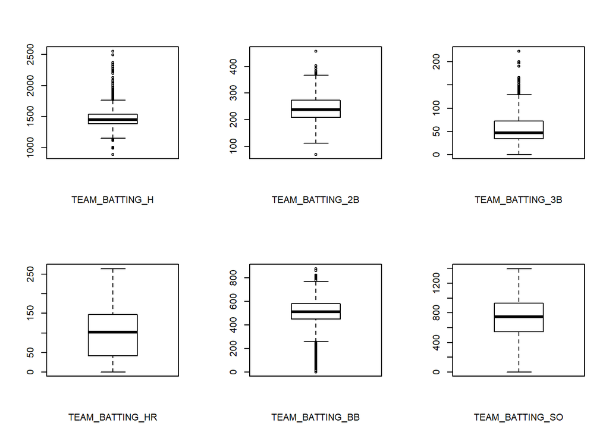

[figure not shown]

[figure not shown]

[figure not shown]

```r
par(mfrow=c(2,3))
x <- c(1:6)
for (val in x) {
  boxplot(MB_train_bat[,val], xlab=names(MB_train_bat[val]))$out
}
```

### Relationship with target variable TARGET_WIN

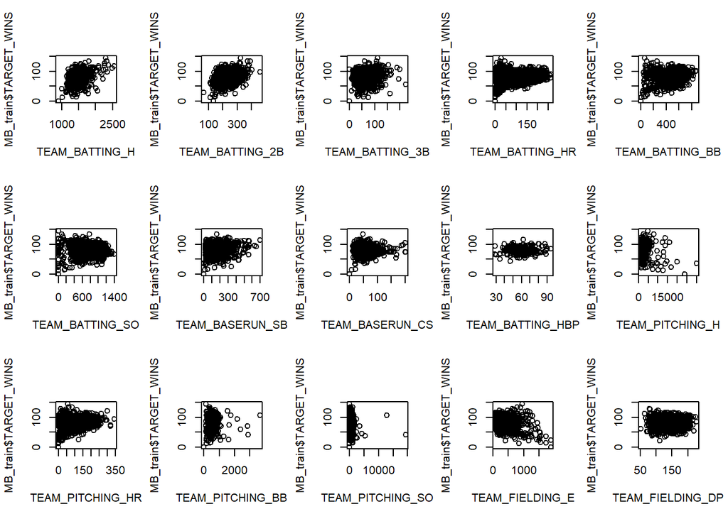

```r
#### Target Wins vs all variables
par(mfrow=c(3,5))
x <- c(2:16)
for (val in x) {
plot(MB_train[,val],MB_train$TARGET_WINS, xlab=names(MB_train[val]))
}
```

## Finding Correlation among predictor variables

```r
par(mfrow=c(1,1))
cor(MB_train, use = "complete.obs")[,1]
```

```
##      TARGET_WINS   TEAM_BATTING_H  TEAM_BATTING_2B  TEAM_BATTING_3B
##       1.00000000       0.46994665       0.31298400      -0.12434586
##  TEAM_BATTING_HR  TEAM_BATTING_BB  TEAM_BATTING_SO  TEAM_BASERUN_SB
##       0.42241683       0.46868793      -0.22889273       0.01483639
##  TEAM_BASERUN_CS TEAM_BATTING_HBP  TEAM_PITCHING_H TEAM_PITCHING_HR
##      -0.17875598       0.07350424       0.47123431       0.42246683
## TEAM_PITCHING_BB TEAM_PITCHING_SO  TEAM_FIELDING_E TEAM_FIELDING_DP
##       0.46839882      -0.22936481      -0.38668800      -0.19586601
```

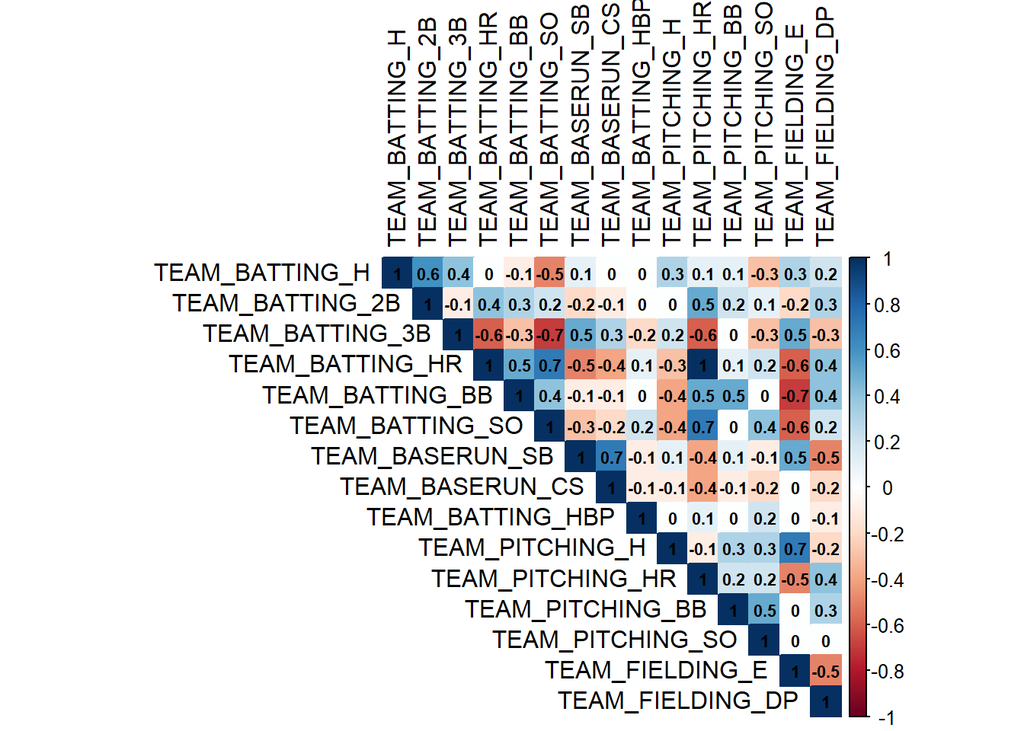

```r
corr<- round(cor(MB_train[-1], use="pairwise.complete.obs", method = "pearson"),1)
corrplot(corr, method = "color",
         type = "upper", order = "original", number.cex = .7,
         addCoef.col = "black", # Add coefficient of correlation
         tl.col = "black", tl.srt = 90, # Text label color and rotation
                  # hide correlation coefficient on the principal diagonal
         diag = TRUE)
```

The record number of strikeouts by a pitching staff in a season is 1,687 by the Houston Astros in 2018 (this datapoint is not included here since the data only covers up to 2006). Since some of the data is extrapolated to assume a 162 game season, it’s possible some earlier seasons may equate to more, so let’s use 2000 as a max possible value.

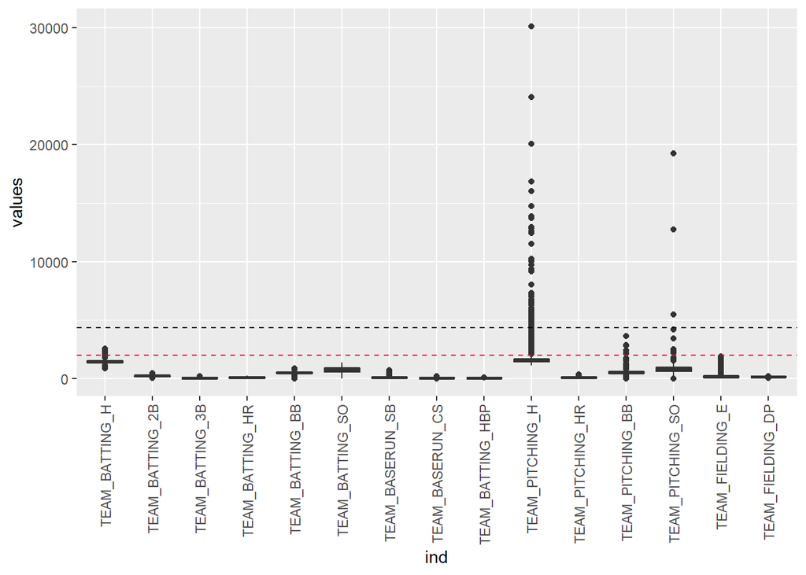

```r
Max_SO <- 162*9*3 #This assumes a season in which every out was a strikeout (obviously never happened)

ggplot(stack(MB_train[,-1]), aes(x = ind, y = values)) +
  geom_boxplot() +
  theme(axis.text.x = element_text(angle = 90, vjust = 0.5, hjust = 1)) +   geom_hline(yintercept=Max_SO, linetype = 'dashed') +
  geom_hline(yintercept=2000, linetype = 'dashed', color='red')
```

According to [MLB.com](http://mlb.mlb.com/mlb/history/rare_feats/index.jsp?feature=most_hits_game) the most hits allowed in a game was 33. Assuming a 162 game seaosn, the highest number of hits allowed in a season possible would be $162*33 = 5346$ hits. Anything above this is impossible.

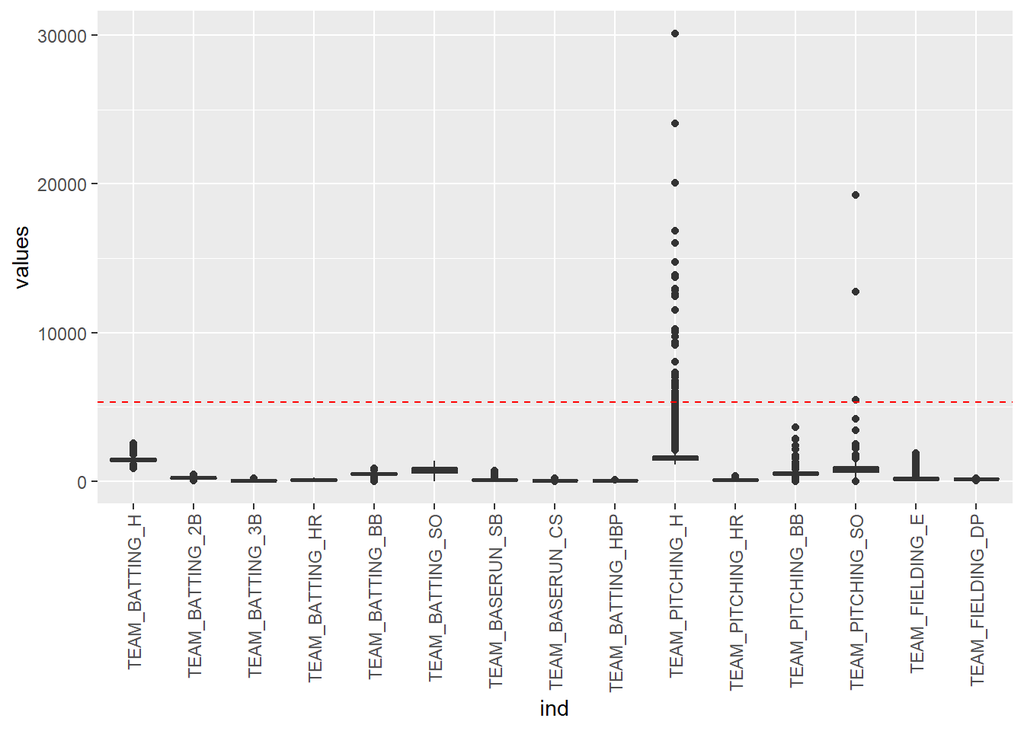

```r
most_hits <- 162*33

ggplot(stack(MB_train[,-1]), aes(x = ind, y = values)) +
  geom_boxplot() +
  theme(axis.text.x = element_text(angle = 90, vjust = 0.5, hjust = 1)) +
  geom_hline(yintercept=most_hits, linetype = 'dashed', color='red')
```

Based on the graph above, it looks like we are potentially leaving a large amount of erroneous data in the set, but we have no factual basis to remove it on.

## Cleaning Data based on what we know so far

We can clearly see that there is a fair amount of outliers in our data. To begin, let’s simply remove these rows of data since we can’t have faith in the rest of the data associated with the measurement. We can also remove the rows associated with other clearly erroneous data:

- No team has ever hit 0 home runs in a season according to [baseball-almanac1](https://www.baseball-almanac.com/recbooks/rb_hr7.shtml), so remove rows that claim such a season.
- No team has ever had 0 hitter strikeouts in a season according to [baseball-almanac2](https://www.baseball-almanac.com/recbooks/rb_strike2.shtml), so remove rows that claim such a season.
- According to [this article](http://research.sabr.org/journals/pitchers-giving-up-home-runs#:~:text=The%20fewest%20home%20runs%20given,more%20productive%20home%20run%20year.) "The fewest home runs given up by a pitching staff in one season was the four relinquished by the marvelous mound corps of the 1902 Pittsburgh Pirates over a 140-game schedule.
- Trusting the [research of user BowlOfRed](https://sports.stackexchange.com/questions/16246/what-is-the-mlb-record-for-most-errors-by-one-team-in-one-season-during-the-mode) the highest number of errors by a team in a season is Washington in 1886 committing 867 errors in 122 games. If we extrapolate that number to 162 games we can cut out the false data points here as well.

```r
most_hits <- 162*33
max_errors <- 867/122*162
Max_SO <- 162*9*3 #This assumes a season in which every out was a strikeout (obviously never happened)
MB_train_clean <- MB_train[!(MB_train$TEAM_PITCHING_SO > 2000),]
MB_train_clean <- MB_train_clean[!(MB_train_clean$TEAM_BATTING_HR == 0),]
MB_train_clean <- MB_train_clean[!(MB_train_clean$TEAM_BATTING_SO == 0),]
MB_train_clean <- MB_train_clean[!(MB_train_clean$TEAM_PITCHING_HR < 4),]
MB_train_clean <- MB_train_clean[!(MB_train_clean$TEAM_PITCHING_H > most_hits),]
MB_train_clean <- MB_train_clean[!(MB_train_clean$TEAM_FIELDING_E > max_errors),]
```

#### Impute Missing Data

We can see that a large amount of datapoints are missing. Let’s replace the NA’s with the mean value for each column.

```r
for(i in 1:ncol(MB_train_clean)){
  MB_train_clean[is.na(MB_train_clean[,i]), i] <- mean(MB_train_clean[,i], na.rm = TRUE)
}
```

## Visualizations of cleaned data

Another look at the variables. Being able to examine Skewness and outliers of the data will help us to chose the model. This is important as some models will require transformation of data.

[figure not shown]

```r
par(mfrow = c(3,5))
datasub = melt(MB_train_clean)
```

```
## Using  as id variables
```

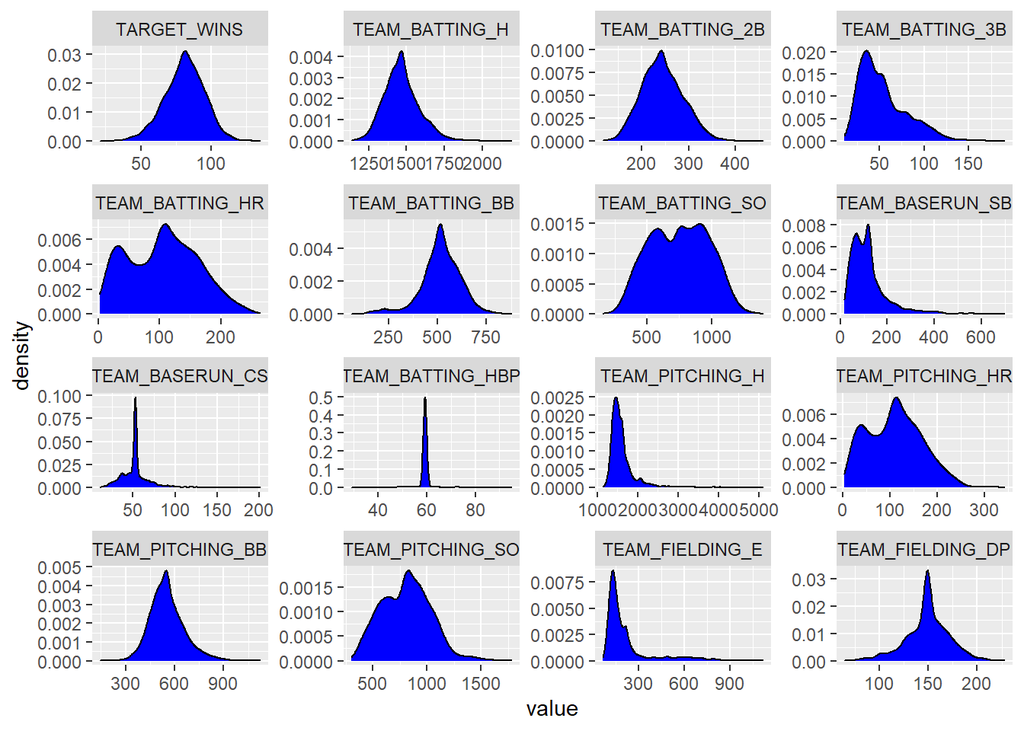

```r
ggplot(datasub, aes(x=value)) +
  geom_density(fill = 'blue') + facet_wrap(~variable, scales = 'free')
```

## Prediction models

To begin let’s take a look at the model using all of the original data. This model includes all outliers that we looked over in the section above.

```r
model0 <- lm(TARGET_WINS ~., data = MB_train)
summary(model0)
```

```
##
## Call:
## lm(formula = TARGET_WINS ~ ., data = MB_train)
##
## Residuals:
##      Min       1Q   Median       3Q      Max
## -19.8708  -5.6564  -0.0599   5.2545  22.9274
##
## Coefficients:
##                  Estimate Std. Error t value Pr(>|t|)
## (Intercept)      60.28826   19.67842   3.064  0.00253 **
## TEAM_BATTING_H    1.91348    2.76139   0.693  0.48927
## TEAM_BATTING_2B   0.02639    0.03029   0.871  0.38484
## TEAM_BATTING_3B  -0.10118    0.07751  -1.305  0.19348
## TEAM_BATTING_HR  -4.84371   10.50851  -0.461  0.64542
## TEAM_BATTING_BB  -4.45969    3.63624  -1.226  0.22167
## TEAM_BATTING_SO   0.34196    2.59876   0.132  0.89546
## TEAM_BASERUN_SB   0.03304    0.02867   1.152  0.25071
## TEAM_BASERUN_CS  -0.01104    0.07143  -0.155  0.87730
## TEAM_BATTING_HBP  0.08247    0.04960   1.663  0.09815 .
## TEAM_PITCHING_H  -1.89096    2.76095  -0.685  0.49432
## TEAM_PITCHING_HR  4.93043   10.50664   0.469  0.63946
## TEAM_PITCHING_BB  4.51089    3.63372   1.241  0.21612
## TEAM_PITCHING_SO -0.37364    2.59705  -0.144  0.88577
## TEAM_FIELDING_E  -0.17204    0.04140  -4.155 5.08e-05 ***
## TEAM_FIELDING_DP -0.10819    0.03654  -2.961  0.00349 **
## ---
## Signif. codes:  0 '***' 0.001 '**' 0.01 '*' 0.05 '.' 0.1 ' ' 1
##
## Residual standard error: 8.467 on 175 degrees of freedom
##   (2085 observations deleted due to missingness)
## Multiple R-squared:  0.5501, Adjusted R-squared:  0.5116
## F-statistic: 14.27 on 15 and 175 DF,  p-value: < 2.2e-16
```

We can clearly see that only a few (3) of our variables seem to have low enough p-values to be deemed statistically significant predictors. There are also 2085 observation deleted due to missing data - this is a very large chunk of wasted datapoints!

Next let’s create a model that removes the outliers and patently false values identified in the previous section as well as the missing datapoints.

### Model 1

```r
model1 <- lm(TARGET_WINS ~., data = MB_train_clean)
summary(model1)
```

```
##
## Call:
## lm(formula = TARGET_WINS ~ ., data = MB_train_clean)
##
## Residuals:
##     Min      1Q  Median      3Q     Max
## -51.923  -7.504   0.000   7.492  67.865
##
## Coefficients:
##                   Estimate Std. Error t value Pr(>|t|)
## (Intercept)      28.239071   6.952878   4.061 5.05e-05 ***
## TEAM_BATTING_H    0.014808   0.005444   2.720 0.006576 **
## TEAM_BATTING_2B  -0.019688   0.009059  -2.173 0.029859 *
## TEAM_BATTING_3B   0.139605   0.017975   7.767 1.23e-14 ***
## TEAM_BATTING_HR   0.197748   0.055627   3.555 0.000386 ***
## TEAM_BATTING_BB   0.107079   0.016291   6.573 6.14e-11 ***
## TEAM_BATTING_SO  -0.053991   0.009403  -5.742 1.06e-08 ***
## TEAM_BASERUN_SB   0.044307   0.004676   9.476  < 2e-16 ***
## TEAM_BASERUN_CS  -0.014355   0.015313  -0.937 0.348637
## TEAM_BATTING_HBP  0.081460   0.066341   1.228 0.219617
## TEAM_PITCHING_H   0.015360   0.002346   6.547 7.28e-11 ***
## TEAM_PITCHING_HR -0.104425   0.051629  -2.023 0.043234 *
## TEAM_PITCHING_BB -0.078529   0.014513  -5.411 6.95e-08 ***
## TEAM_PITCHING_SO  0.041993   0.008354   5.027 5.39e-07 ***
## TEAM_FIELDING_E  -0.039787   0.003638 -10.938  < 2e-16 ***
## TEAM_FIELDING_DP -0.077240   0.013038  -5.924 3.64e-09 ***
## ---
## Signif. codes:  0 '***' 0.001 '**' 0.01 '*' 0.05 '.' 0.1 ' ' 1
##
## Residual standard error: 11.84 on 2202 degrees of freedom
## Multiple R-squared:  0.3006, Adjusted R-squared:  0.2958
## F-statistic: 63.08 on 15 and 2202 DF,  p-value: < 2.2e-16
```

We can immediately see how much more statistically significant each of our cleaned predictors are - nearly every single p-value is noticeably lower than it was in the initial model. This suggests that the data in this model is more likely to have a relationship with our target variable.

#### Diagnostics plots

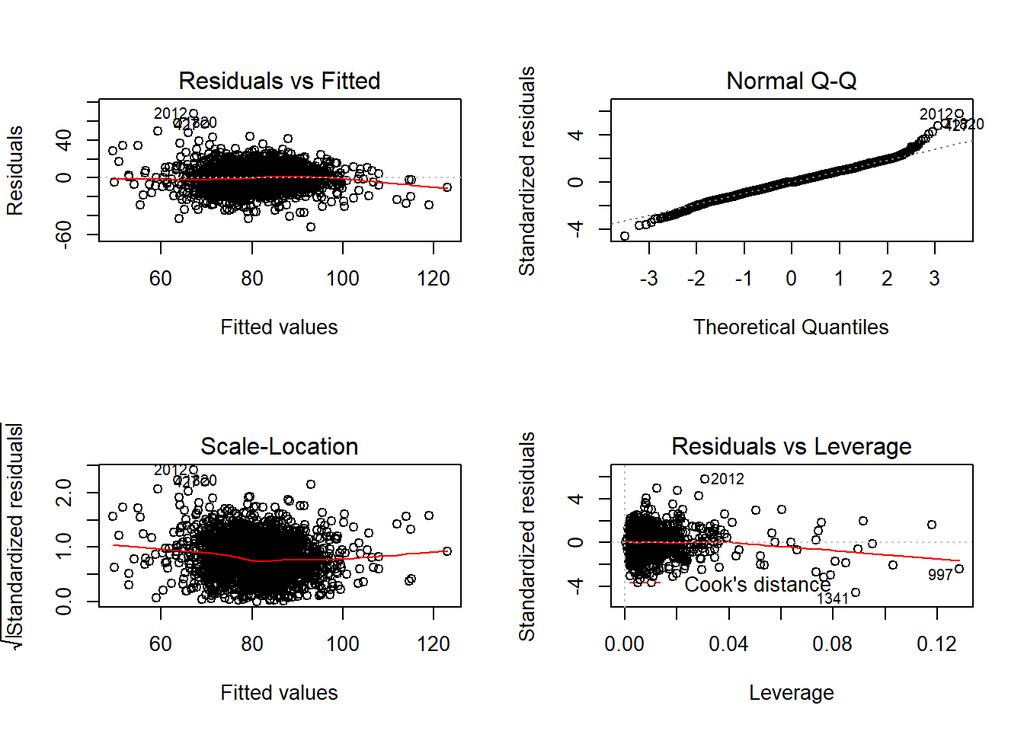

```r
par(mfrow=c(2,2))
plot(model1)
```

### Model 2

Variables will be removed one by one until the most optimal output is achieved. We did this in order to remove those features that do not have a significant effect on the dependent variable or prediction of output and simplify our model. To start we wikll remove the variables with the highest p-values.

```
##
## Call:
## lm(formula = TARGET_WINS ~ . - TEAM_BASERUN_CS - TEAM_BATTING_HBP,
##     data = MB_train_clean)
##
## Residuals:
##     Min      1Q  Median      3Q     Max
## -51.950  -7.526   0.000   7.489  67.737
##
## Coefficients:
##                   Estimate Std. Error t value Pr(>|t|)
## (Intercept)      31.970344   5.694430   5.614 2.22e-08 ***
## TEAM_BATTING_H    0.014872   0.005444   2.732 0.006348 **
## TEAM_BATTING_2B  -0.019862   0.009058  -2.193 0.028432 *
## TEAM_BATTING_3B   0.139146   0.017974   7.742 1.48e-14 ***
## TEAM_BATTING_HR   0.203085   0.055296   3.673 0.000246 ***
## TEAM_BATTING_BB   0.104805   0.016137   6.495 1.03e-10 ***
## TEAM_BATTING_SO  -0.052917   0.009361  -5.653 1.78e-08 ***
## TEAM_BASERUN_SB   0.042941   0.004485   9.574  < 2e-16 ***
## TEAM_PITCHING_H   0.015293   0.002345   6.520 8.68e-11 ***
## TEAM_PITCHING_HR -0.107818   0.051486  -2.094 0.036365 *
## TEAM_PITCHING_BB -0.076129   0.014327  -5.314 1.18e-07 ***
## TEAM_PITCHING_SO  0.041055   0.008313   4.939 8.46e-07 ***
## TEAM_FIELDING_E  -0.038959   0.003557 -10.952  < 2e-16 ***
## TEAM_FIELDING_DP -0.077138   0.013026  -5.922 3.68e-09 ***
## ---
## Signif. codes:  0 '***' 0.001 '**' 0.01 '*' 0.05 '.' 0.1 ' ' 1
##
## Residual standard error: 11.84 on 2204 degrees of freedom
## Multiple R-squared:  0.2998, Adjusted R-squared:  0.2957
## F-statistic: 72.59 on 13 and 2204 DF,  p-value: < 2.2e-16
```

#### Diagnostics plots

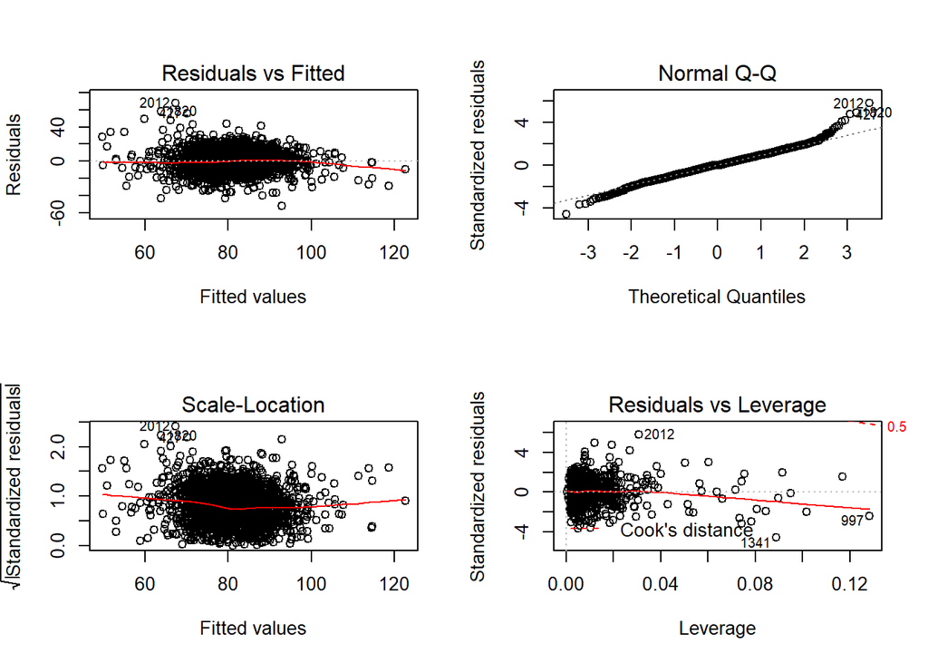

```r
par(mfrow=c(2,2))
plot(model2)
```

### Model 3

This model will focus only on the variables that are maximally statistically significant - in order to see if only those variables allow for a better model.

#### Summary and vif

```
##
## Call:
## lm(formula = TARGET_WINS ~ . - TEAM_BASERUN_CS - TEAM_BATTING_HBP -
##     TEAM_BATTING_H - TEAM_BATTING_2B - TEAM_PITCHING_HR, data = MB_train_clean)
##
## Residuals:
##     Min      1Q  Median      3Q     Max
## -46.454  -7.537   0.000   7.476  68.149
##
## Coefficients:
##                   Estimate Std. Error t value Pr(>|t|)
## (Intercept)      41.097981   4.186019   9.818  < 2e-16 ***
## TEAM_BATTING_3B   0.151931   0.016258   9.345  < 2e-16 ***
## TEAM_BATTING_HR   0.095681   0.008798  10.876  < 2e-16 ***
## TEAM_BATTING_BB   0.122744   0.013833   8.873  < 2e-16 ***
## TEAM_BATTING_SO  -0.042450   0.008542  -4.970 7.22e-07 ***
## TEAM_BASERUN_SB   0.044993   0.004371  10.294  < 2e-16 ***
## TEAM_PITCHING_H   0.019730   0.001533  12.873  < 2e-16 ***
## TEAM_PITCHING_BB -0.093053   0.012048  -7.724 1.70e-14 ***
## TEAM_PITCHING_SO  0.029066   0.007313   3.975 7.27e-05 ***
## TEAM_FIELDING_E  -0.037287   0.003158 -11.805  < 2e-16 ***
## TEAM_FIELDING_DP -0.072405   0.012752  -5.678 1.54e-08 ***
## ---
## Signif. codes:  0 '***' 0.001 '**' 0.01 '*' 0.05 '.' 0.1 ' ' 1
##
## Residual standard error: 11.86 on 2207 degrees of freedom
## Multiple R-squared:  0.2963, Adjusted R-squared:  0.2932
## F-statistic: 92.95 on 10 and 2207 DF,  p-value: < 2.2e-16
```

```r
vif(model3)
```

```
##  TEAM_BATTING_3B  TEAM_BATTING_HR  TEAM_BATTING_BB  TEAM_BATTING_SO
##         2.895882         3.945930        33.232173        57.805669
##  TEAM_BASERUN_SB  TEAM_PITCHING_H TEAM_PITCHING_BB TEAM_PITCHING_SO
##         2.052647         4.955136        25.999917        43.298983
##  TEAM_FIELDING_E TEAM_FIELDING_DP
##         4.233002         1.247533
```

#### Diagnostics plots

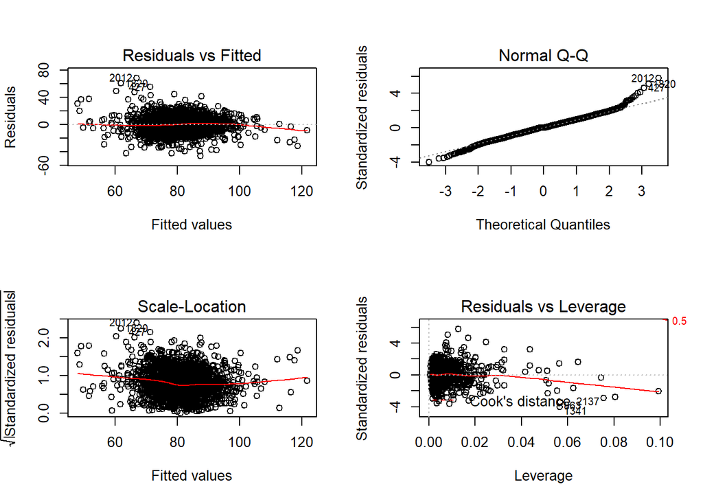

```r
par(mfrow=c(2,2))
plot(model3)
```

Looking at the plots above we can see a fairly linear Q-Q plot outside of the extreme values. The standardized residuals also appear to be fairly randomly distributed, another good sign.

Oddly enough, the strikeout metrics (along with the Fielding DP) have the highest p-values, so we can further simplify our model by removing them and see how that impacts our model.

```r
model4 <- lm(TARGET_WINS ~ . - TEAM_BASERUN_CS - TEAM_BATTING_HBP - TEAM_BATTING_H    - TEAM_BATTING_2B -  TEAM_PITCHING_HR - TEAM_BATTING_SO - TEAM_PITCHING_SO - TEAM_FIELDING_DP, data= MB_train_clean)
summary(model4)
```

```
##
## Call:
## lm(formula = TARGET_WINS ~ . - TEAM_BASERUN_CS - TEAM_BATTING_HBP -
##     TEAM_BATTING_H - TEAM_BATTING_2B - TEAM_PITCHING_HR - TEAM_BATTING_SO -
##     TEAM_PITCHING_SO - TEAM_FIELDING_DP, data = MB_train_clean)
##
## Residuals:
##     Min      1Q  Median      3Q     Max
## -45.676  -7.720   0.000   7.681  65.082
##
## Coefficients:
##                   Estimate Std. Error t value Pr(>|t|)
## (Intercept)      17.910403   2.768168   6.470  1.2e-10 ***
## TEAM_BATTING_3B   0.169952   0.014891  11.413  < 2e-16 ***
## TEAM_BATTING_HR   0.060278   0.006989   8.624  < 2e-16 ***
## TEAM_BATTING_BB   0.088487   0.008928   9.911  < 2e-16 ***
## TEAM_BASERUN_SB   0.038427   0.003988   9.635  < 2e-16 ***
## TEAM_PITCHING_H   0.024650   0.001375  17.923  < 2e-16 ***
## TEAM_PITCHING_BB -0.062429   0.007514  -8.308  < 2e-16 ***
## TEAM_FIELDING_E  -0.035933   0.003059 -11.746  < 2e-16 ***
## ---
## Signif. codes:  0 '***' 0.001 '**' 0.01 '*' 0.05 '.' 0.1 ' ' 1
##
## Residual standard error: 12.02 on 2210 degrees of freedom
## Multiple R-squared:  0.2765, Adjusted R-squared:  0.2742
## F-statistic: 120.7 on 7 and 2210 DF,  p-value: < 2.2e-16
```

## Prediction

Let’s attempt a prediction using the latest model. To do so we must take a subset of our test dataset that includes only the columns we choose to use in the prediction.

```r
MB_test<- read.csv("https://raw.githubusercontent.com/mkollontai/DATA621_GroupWork/master/HW1/moneyball-evaluation-data.csv")
```

Let’s identify all of the rows containing obvious outliers in the data:

```r
Out <- function(x){
  if (x[2] > most_hits * 1.25 | x[11] > most_hits*1.25) {
    return (1)
  } else if (x[7] > Max_SO | x[14] > Max_SO) {
    return (1)
  } else if (x[15] > max_errors){
    return (1)
  } else {
    return (0)
  }
}
```

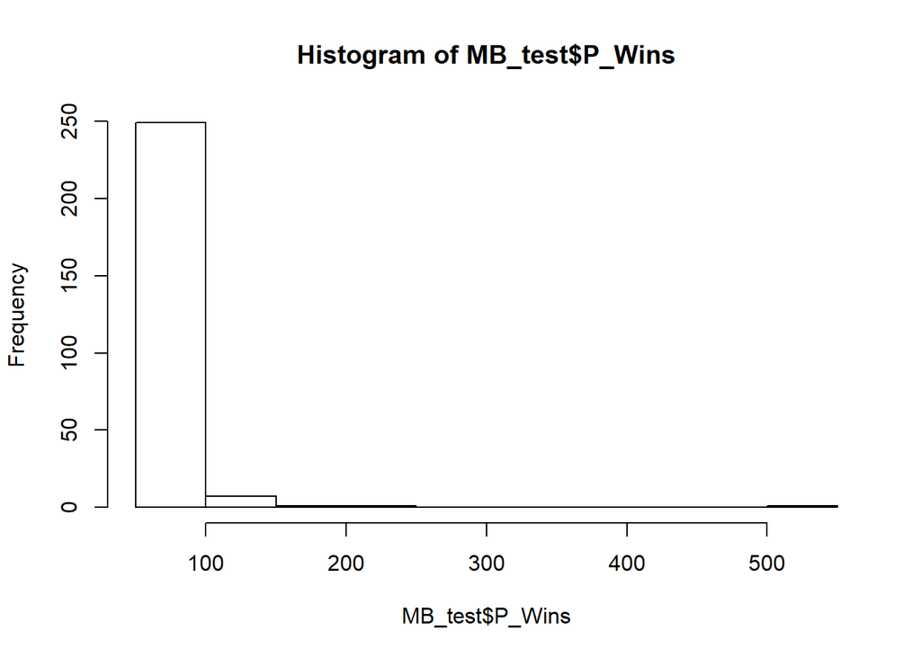

```r
#First we replace NAs with the median values
for(i in 1:ncol(MB_test)){
  MB_test[is.na(MB_test[,i]), i] <- median(MB_test[,i], na.rm = TRUE)
}

MB_test$Outliers <- apply(MB_test, 1, FUN = Out)
MB_test$P_Wins <- round(predict(model4,  newdata = MB_test),0)
hist(MB_test$P_Wins)
```

Based on this histogram we can see that there are some obvious outliers in our predictions. Let us look only at the rows not tagged as having outliers in the variables used for prediction.

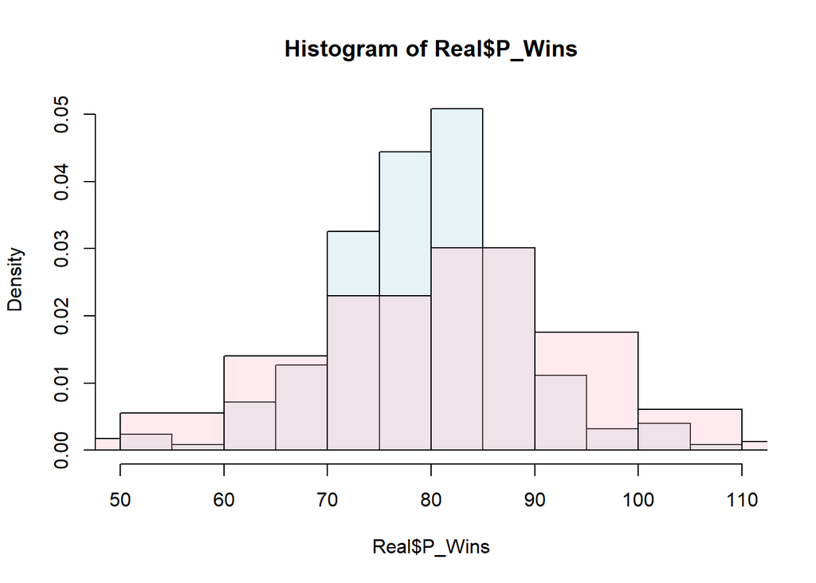

```r
plot(histA, col = c1, freq = FALSE)
plot(histB, col = c2, freq = FALSE, add = TRUE, xlim = c(0,150))
```

We can’t test out the accuracy of our model as we don’t have the true ‘Win’ values for our test dataset, but below see a list of the predicted wins for all of the rows not containing outliers in the data:

```r
Real[c('INDEX','P_Wins')]
```

```
##     INDEX P_Wins
## 1       9     67
## 2      10     69
## 3      14     73
## 4      47     84
## 5      60    100
## 6      63     72
## 7      74     76
## 8      83     68
## 9      98     73
## 10    120     71
## 11    123     71
## 12    135     83
## 13    138     84
## 14    140     78
```

[output cut: 238 more lines]

## Potential Future Work

One approach we looked into pursuing was to split up the data into ‘Batting’, ‘Baserun’, ‘Pitching’ and ‘Fielding’ data and investigating whether or not some trends hold true for one category, but not others. Perhaps apply uniform coefficients across the categories.